# 303.2. Galaxy shapes in DP2

For the Rubin Science Platform at data.lsst.cloud.  
Data Release: [Data Preview 2](https://dp2.lsst.io/)  
Container Size: Large  
LSST Science Pipelines version: r30.0.11  
Last verified to run: 2026-09-04  
Repository: github.com/lsst/tutorial-notebooks  
DOI: 10.11578/rubin/dc.20250909.20

**Learning objective:** Explore the available measurements of galaxy shapes produced by the LSST pipelines and their applications.

**LSST data products:** Object, deep_coadd

**Packages:** `lsst.afw`, `lsst.rsp`, `lsst.geom`, `lsst.gauss2d`, `astropy`, `photutils`, `galsim`

**Credit:** Originally developed by the Rubin Community Science team. Please consider acknowledging them if this notebook is used for the preparation of journal articles, software releases, or other notebooks.

**Get Support:** Everyone is encouraged to ask questions or raise issues in the [Support Category](https://community.lsst.org/c/support) of the Rubin Community Forum. Rubin staff will respond to all questions posted there.

## 1. Introduction

The LSST Science Pipelines make a variety of automated shape and morphology measurements for extended sources that are useful for galaxy evolution science. This notebook will teach the user about these measurements. They are performed on the `deep_coadd` images and appear in the `Object` table as part of the LSST pipelines data products. The focus will be on galaxies. Data products related to shapes for the purpose of cosmological analyses will be demonstrated elsewhere.

### 1.1. Import packages

Import `numpy`, a fundamental package for scientific computing with arrays in Python (numpy.org), and `matplotlib`, a comprehensive library for data visualization ([matplotlib.org](https://matplotlib.org/); [matplotlib gallery](https://matplotlib.org/stable/gallery/index.html)). The `io` package provides input and output functions for handling data transfer.

From the `pyvo` package, import some functions that will enable using the image cutout tool. From `astropy` and `photutils` import packages to enable plotting images and drawing shapes on images with WCS information.

From the `lsst` package, import modules for accessing the Table Access Protocol (TAP) service, and image display functions from the LSST Science Pipelines ([pipelines.lsst.io](https://pipelines.lsst.io/)). Also import some geometric functions to help plot photometric apertures.

Finally, import `galsim` which is the galaxy simulation package, which was used to build the DP0.2 simulated images. This package and the lsst package `gauss2d` are useful for reconstructing the sersic profiles that are used to model the galaxies in Rubin images.

```python
import numpy as np
import matplotlib.pyplot as plt
import io

from pyvo.dal.adhoc import SodaQuery

from astropy.coordinates import SkyCoord
import astropy.units as u

from photutils.aperture import SkyEllipticalAperture

from lsst.rsp import RSPDiscovery
from lsst.rsp.utils import get_pyvo_auth
import lsst.afw.display as afwDisplay
import lsst.afw.geom.ellipses as ellipses
from lsst.gauss2d import Ellipse, EllipseMajor, Covariance
from lsst.images.serialization import read_archive

import galsim as gs
```

### 1.2. Define parameters and functions

Define a function to generate an image cutout, using the Rubin image cutout service. Further information about the cutout tool can be found in DP2 tutorial notebook 103.6 that demonstrates the Rubin image cutout service.

Since more than one `deep_coadd` can overlap any galaxy, and sometimes objects can be too close to the `deep_coadd` edge to generate a usable cutout, this function also performs a check for which overlapping `deep_coadd` is the best (the object is closest to its center; indicated by `best_index`).

```python
def make_image_cutout(ra, dec, cutout_size=0.01, band='i'):
    """
    Wrapper function to generate a cutout using the cutout tool.
    Default is to show cutout in i-band.

    Parameters
    ----------
    ra, dec : 'float'
        the ra and dec of the cutout center
    cutout_size : 'float', optional
        radial edge length in degrees of the cutout

    Returns
    -------
    cutout : 'lsst.images object'
    """

    sia_client = discovery.get_sia_client()

    eff_wl = 622.1e-09
    circle = (ra, dec, cutout_size)

    results = sia_client.search(pos=circle, calib_level=3,
                                dpsubtype='lsst.deep_coadd',
                                band=eff_wl)

    if len(results) == 0:
        raise ValueError(f"No images found for RA={ra}, Dec={dec}")

    table = results.to_table()
    distances = ((table['s_ra'] - ra)**2 + (table['s_dec'] - dec)**2)**0.5
    best_index = int(distances.argmin())
    dl_result = discovery.get_datalink_results(results[best_index])

    f"Datalink status: {dl_result.status}."

    sq = SodaQuery.from_resource(dl_result,
                                 dl_result.get_adhocservice_by_id("cutout-sync-exposure"),
                                 session=get_pyvo_auth())

    cutout_ra = ra * u.deg
    cutout_dec = dec * u.deg
    Radius = cutout_size * u.deg

    sq.circle = (cutout_ra, cutout_dec, Radius)
    cutout_bytes = sq.execute_stream().read()
    sq.raise_if_error()

    cutout = read_archive(io.BytesIO(cutout_bytes))
    return cutout
```

Define parameters to use colorblind-friendly colors with `matplotlib`.

```python
plt.style.use('seaborn-v0_8-colorblind')
prop_cycle = plt.rcParams['axes.prop_cycle']
colors = prop_cycle.by_key()['color']
```

Set the `afwDisplay` backend to `matplotlib` to enable use of various packages to overplot on images.

```python
afwDisplay.setDefaultBackend('matplotlib')
```

Instantiate `RSPDiscovery` with the DP2 release, create an instance of the TAP service, and assert that it exists.

```python
discovery = RSPDiscovery("dp2")
service = discovery.get_tap_client()
```

## 2. Find galaxies in ECDFS

One of the deep drilling fields in the DP2 is the Extended Chandra Deep Field South (ECDFS). This section uses a galaxy that was previously identified in ECDFS that is known to be large and edge-on.

```python
target_ra = 53.19488194
target_dec = -27.70342546
```

Here, query the DP2 `Object` table for the morphological parameters for this galaxy. Check that the identified galaxy is extended (`i_extendedness` = 1), that its `i_kronFlux_flag_*`, `sersic_no_data_flag`, and `shape_flag` are all = 0, indicating there is not a problem with modeling the shape and light profile.

Pick a very small search radius of 0.72 arcseconds to ensure the return is the previously specified large, edge-on galaxy.

The query will retrieve a number of shape measurements and flags that will be explained in Section 3.

```python
query = "SELECT obj.objectId, obj.coord_ra, obj.coord_dec, " + \
        "obj.i_extendedness, obj.refBand, " + \
        "obj.i_kronFlux, obj.i_kronRad, obj.i_kronFlux_flag, " + \
        "obj.i_kronFlux_flag_small_radius, obj.i_kronFlux_flag_bad_radius, " + \
        "obj.shape_xx, obj.shape_xy, obj.shape_yy, obj.shape_flag, " + \
        "obj.i_ixx, obj.i_ixy, obj.i_iyy, " + \
        "obj.i_sersicFlux, obj.i_exponentialFlux,  obj.sersic_no_data_flag, " + \
        "obj.sersic_index, obj.sersic_reff_x, " + \
        "obj.sersic_reff_y, obj.sersic_rho, " + \
        "obj.sersic_reff_major, obj.sersic_reff_minor, obj.sersic_theta, " + \
        "obj.i_cModel_dev_reff_major, obj.i_cModel_dev_reff_minor, obj.i_cModel_dev_theta, " + \
        "obj.i_cModel_exp_reff_major, obj.i_cModel_exp_reff_minor, obj.i_cModel_exp_theta, " + \
        "obj.i_cModelFlux, obj.i_cModel_fracDev, " + \
        "obj.exponential_reff_major, obj.exponential_reff_minor, obj.exponential_theta " + \
        "FROM dp2.Object AS obj " + \
        "WHERE (obj.i_extendedness = 1) AND (obj.shape_flag = 0) AND " + \
        "(obj.i_kronFlux_flag_small_radius = 0) AND " + \
        "(obj.i_kronFlux_flag_bad_radius = 0) AND " + \
        "(obj.i_kronFlux_flag = 0) AND (obj.sersic_no_data_flag = 0) AND " + \
        "CONTAINS(POINT('ICRS', obj.coord_ra, obj.coord_dec), " + \
        "CIRCLE('ICRS',"+str(target_ra)+","+str(target_dec)+", 0.0002)) = 1 "
```

```python
job = service.submit_job(query)
job.run()
job.wait(phases=['COMPLETED', 'ERROR'])
print('Job phase is', job.phase)
```

```
Job phase is COMPLETED
```

```python
results = job.fetch_result()
tab = results.to_table()
tab
```

*Table length=1*

| objectId int64 | coord_ra deg float64 | coord_dec deg float64 | i_extendedness float32 | refBand str1 | i_kronFlux nJy float32 | i_kronRad pix float32 | i_kronFlux_flag bool | i_kronFlux_flag_small_radius bool | i_kronFlux_flag_bad_radius bool | shape_xx pix2 float32 | shape_xy pix2 float32 | shape_yy pix2 float32 | shape_flag bool | i_ixx pix2 float32 | i_ixy pix2 float32 | i_iyy pix2 float32 | i_sersicFlux nJy float32 | i_exponentialFlux nJy float32 | sersic_no_data_flag bool | sersic_index float32 | sersic_reff_x pix float32 | sersic_reff_y pix float32 | sersic_rho float32 | sersic_reff_major arcsec float32 | sersic_reff_minor arcsec float32 | sersic_theta float32 | i_cModel_dev_reff_major arcsec float32 | i_cModel_dev_reff_minor arcsec float32 | i_cModel_dev_theta float32 | … |
| --- | --- | --- | --- | --- | --- | --- | --- | --- | --- | --- | --- | --- | --- | --- | --- | --- | --- | --- | --- | --- | --- | --- | --- | --- | --- | --- | --- | --- | --- | --- |
| 755370947912955099 | 53.194873939824234 | -27.703425524958117 | 1.0 | i | 1.52285e+06 | 12.5642 | False | False | False | 49.6591 | 30.993 | 50.6145 | False | 49.6591 | 30.993 | 50.6145 | 1.66207e+06 | 1.39646e+06 | False | 2.20258 | 9.38052 | 9.53709 | 0.785649 | 2.52803 | 0.875735 | -45.5537 | 6.28992 | 2.26001 | -45.6413 | … |

## 3. Visualize galaxy morphology

This section will make an image cutout of the large galaxy, and compare the shapes of the different photometric and morphological measurements. This section demonstrates how to reconstruct the Gaussian Ellipse, Kron ellipse, and Sersic half-light shape, using the corresponding shape parameters in the `Object` table.

Below, define the `SkyCoord` for the galaxy's location.

```python
coord = SkyCoord(ra=tab['coord_ra'][0]*u.degree,
                 dec=tab['coord_dec'][0]*u.degree, frame='icrs')
```

The sizes in the LSST `Object` table are in units of pixel. Note that the pixel scale of the LSST data is 0.2 arcseconds per pixel. Define the conversion in the cell below.

```python
arcsec_per_pix = 0.2
```

### 3.1. Gaussian ellipse

In the next cell, use `Object` table shape parameters to reconstruct the galaxy shape, approximated as a 2D Gaussian. The LSST pipelines measures this shape, parameterized by three parameters or "moments" measured on the `deep_coadd` in each band individually: `<band>_ixx`, `<band>_iyy`, `<band>_ixy` (weak lensing experts may recognize these come from the measured re-Gaussianization method of [Hirata & Seljak 2003](https://ui.adsabs.harvard.edu/abs/2003MNRAS.343..459H/abstract), implemented by [Mandelbaum et al. 2005](https://ui.adsabs.harvard.edu/abs/2005MNRAS.361.1287M/abstract), and called HSM moments. The corresponding moments measured on the reference band or `refBand` are also stored as `shape_xx`, `shape_yy`, and `shape_xy`. These moments have not been corrected for the point spread function (PSF; thus not applicable for weak lensing) but PSF effects are small for galaxy sizes much larger than the PSF. These shape parameters can be converted to more commonly used set of morphological parameters using the LSST package `ellipses`.

The cell below will demonstrate how to extract these more commonly used parameters (e.g. semi-major radius `A` or `Rmaj`, semi-minor radius `B` or `Rmin`, which can be used to obtain the axis ratio `ba` defined as Rmin/Rmaj, and the position angle `theta`. `theta` is defined in radians counterclockwise from the x-axis.

The semi-major and minor diameters are the "sigmas" of the 2D gaussian model approximation to the light profile. These sizes are unrelated to the Kron photometry or shape, but note that the Kron measurements use the axis ratio and position angle from this measurement.

The 2D Gaussian radius (or equally the Sersic radius) are good metrics of size, and better than kronRad, which can be come uncertain or fail for very small galaxies. Size metrics including Sersic size or gaussian sizes should be used for small galaxies. The kronRad and Kron aperture perform better for large galaxies (i.e. much larger than the PSF).

The example below converts these parameters using the `ellipses` package in `lsst.afw.geom`.

```python
axes = ellipses.Axes(ellipses.Quadrupole(tab['shape_xx'][0],
                                         tab['shape_yy'][0],
                                         tab['shape_xy'][0]))
Rmaj = axes.getA()
Rmin = axes.getB()
theta = axes.getTheta()
```

Equivalently, this could be done using a different set of packages (the cell below demonstrates instead how to use the `ellipse` package in `lsst.gauss2d`). The cell below also validates that the same answer is retrieved with both methods.

```python
ellipse = EllipseMajor(Covariance(sigma_x_sq=tab["shape_xx"][0],
                                  sigma_y_sq=tab["shape_yy"][0],
                                  cov_xy=tab["shape_xy"][0]))

ellipse_Rmaj = ellipse.r_major
ellipse_Rmin = ellipse.axrat * ellipse.r_major
ellipse_theta = ellipse.angle

print(ellipse_Rmaj, Rmaj, ' arcsec')
print(ellipse_Rmin, Rmin, ' arcsec')
print(ellipse_theta, theta, ' radians')
```

```
9.0074125081613 9.0074125081613  arcsec
4.374942013913388 4.374942013913388  arcsec
0.7931041204932631 0.7931041204932631  radians
```

Use `photutils` to define an aperture which enables visualizing the shape parameters on an image cutout. Note that `photutils` convention for `pa` or `theta` is 90 degrees or pi/2 offset from that of the LSST pipeline functions.

```python
gaussell_ellipse = SkyEllipticalAperture(coord,
                                         Rmaj * arcsec_per_pix * u.arcsec,
                                         Rmin * arcsec_per_pix * u.arcsec,
                                         theta=(np.pi/2 + theta) * u.rad)
```

### 3.2. Kron ellipse

In the next cell, reconstruct the Kron aperture. The method of the Kron implementation in the LSST pipelines is to use the `Object` table parameter `<band>_kronRad`, in combination with the same axis-ratio and rotation angle that come from the Gaussian shape parameters from section 3.1.

```python
kronRad = tab['i_kronRad'][0]

R_mom = np.sqrt(Rmaj * Rmin)

kron_aperture_Rmaj = 2.5 * Rmaj * kronRad * arcsec_per_pix / R_mom
kron_aperture_Rmin = 2.5 * Rmin * kronRad * arcsec_per_pix / R_mom
```

Use `photutils` to define the Kron aperture.

```python
kron_aperture = SkyEllipticalAperture(coord,
                                      kron_aperture_Rmaj * u.arcsec,
                                      kron_aperture_Rmin * u.arcsec,
                                      theta=(np.pi/2 + theta) * u.rad)
```

### 3.3. Sersic profiles

#### 3.3.1. Sersic parameters in x-y

Convert the Sersic morphological parameters stored in the `Object` table (the effective Sersic radii in x and y directions, `sersic_reff_x`, `sersic_reff_y`, and the correlation coefficient from the multiband Sersic model fit `sersic_rho` that is related to orientation angle) into the more conventional sersic parameters (axis ratio `ba` defined as the ratio of the semi-minor half-light radius divided to semi-major half-light radius, the position angle `pa`, and the semi-major half-light radius `r_major`). The position angle (`pa`) convention is counter-clockwise relative to the x-axis. In this case, return the `pa` in units of degrees instead of the previous example in radians, to demonstrate its use with `photutils`.

```python
x = EllipseMajor(Ellipse(sigma_x=tab['sersic_reff_x'][0],
                         sigma_y=tab['sersic_reff_y'][0],
                         rho=tab['sersic_rho'][0]), degrees=True)
ba = x.axrat
pa = x.angle
r_major = x.r_major * arcsec_per_pix
```

Use `photutils` to define the Sersic half-light ellipse.

```python
sersic_ellipse = SkyEllipticalAperture(coord,
                                       r_major * u.arcsec,
                                       r_major * ba * u.arcsec,
                                       theta=(pa+90) * u.deg)
```

```python
cutout_size = 0.008

cutout = make_image_cutout(tab['coord_ra'][0], tab['coord_dec'][0],
                           cutout_size=cutout_size)
```

Plot the cutout and overplot the various shapes and apertures. This requires some manipulation of the WCS in order for `lsst.images` and `astropy` to plot consistently.

First, extract the WCS once using the `lsst.images` syntax. This replaces the old `WCS(cutout.getWcs().getFitsMetadata())` from DP1. Then create a subplot with the extracted WCS.

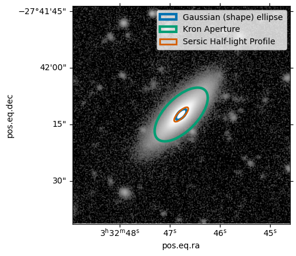

```python
astropy_wcs = cutout.sky_projection.as_fits_wcs(bbox=cutout.bbox)

plt.subplot(projection=astropy_wcs)

plt.imshow(cutout.image.array, origin='lower', cmap='gray', vmin=1,
           vmax=1000, norm='asinh', aspect='equal')

gaussell_pix_ellipse = gaussell_ellipse.to_pixel(astropy_wcs)
gaussell_pix_ellipse.plot(color=colors[0], lw=3, label='Gaussian (shape) ellipse')

kron_pix_aperture = kron_aperture.to_pixel(astropy_wcs)
kron_pix_aperture.plot(color=colors[1], lw=3, label='Kron Aperture')

sersic_pix_ellipse = sersic_ellipse.to_pixel(astropy_wcs)
sersic_pix_ellipse.plot(color=colors[2], lw=2, label='Sersic Half-light Profile')

plt.legend()
```

## 4. Sersic reconstruction

For some science applications it is useful to compare the on-sky image to the Sersic model, for example to assess goodness of fit. The cells below demonstrate how to reconstruct the best-fitting Sersic model that produced the `<band>_sersicFlux`, and represents the morphological parameters stored in the `Object` table.

A straightforward way to do this is using the `galsim`, which is the galaxy simulation package used to build the DP0.2 simulated images. Note that the algorithm used to measure the Sersic fluxes, `multiprofit`, is a Gaussian mixture model that approximates a Sersic model. Renderings of the galaxy using as a pure Sersic model using `galsim` is simpler to plot, but may not be perfectly identical to that built with Gaussian mixture.

It is also good to be aware of objects with Sersic index `n` that are measured to be suspiciously close to 1 (e.g. 1+/- 1e-6). This may happen for poorly fit objects because n=1 is the starting guess, and the optimizer tends to give up if it can't improve within 5-10 iterations.

Below, build the Sersic model using the `galsim` function `gs.Sersic` using the Sersic parameters from the cell above. Note that the total flux of the model very closely approximates the `sersicFlux` from the `Object' table, indicating (in this case) a good fit.

Note that models that exhibit broad wings in the light profile may require a larger cutout to reproduce the measured flux when summing model pixels (e.g. for `cModel` in Section 5.2).

### 4.1. Standard Sersic parameters

New in DP2, the `Object` table now contains standard Sersic parameters (semi-major and minor half-light radii, position angle) which can be used in place of the x-y parameters that were needed in DP1. For this section, as a demonstration, replace those calculated in Section 3.3.1 using the x-y Sersic parameters with the ones stored in the `Object` table.

```python
r_major = tab['sersic_reff_major']
r_minor = tab['sersic_reff_minor']
ba = tab['sersic_reff_minor'] / tab['sersic_reff_major']
pa = tab['sersic_theta'][0] + 90
```

As above, generate the best fit 2D Sersic model of the galaxy. Note that `galsim` takes as input the circularized effective radius, which is defined as `Reff = r_major * sqrt(ba)`.

```
Total flux of model =  1.6613828e+06 nJy, very close to flux from Object table =  1.66207e+06  nJy
```

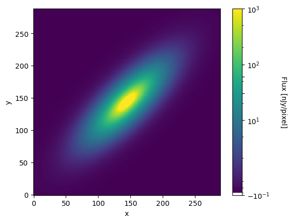

```python
sersic = gs.Sersic(n=tab['sersic_index'][0], half_light_radius=r_major * np.sqrt(ba),
                   flux=tab['i_sersicFlux'][0]).shear(q=ba, beta=pa * gs.degrees)
img_h, img_w = cutout.image.array.shape

sersic_model = sersic.drawImage(nx=img_w, ny=img_h, scale=arcsec_per_pix).array

print('Total flux of model = ', np.sum(sersic_model),
      'nJy, very close to flux from Object table = ',
      tab['i_sersicFlux'][0], ' nJy')

fig, ax = plt.subplots()
im = ax.imshow(sersic_model, origin='lower', interpolation='nearest',
               vmin=0, vmax=1000, norm='asinh')
cbar = fig.colorbar(im, ax=ax)
cbar.set_label('Flux [nJy/pixel]', rotation=270, labelpad=25)
cbar.set_ticks([-0.1, 10, 30, 60, 100, 1000])
plt.xlabel('x')
plt.ylabel('y')
plt.show()
```

> **Figure 2:** The best fit Sersic model of the galaxy in Figure 1 that was used to measure `sersicFlux` of the galaxy.

## 5. Fixed bulge and disk shapes

DP2 contains new shape measurements that can be used to reconstruct the light profiles that model galaxies with fixed Sersic index to `n=1` (`<f>__exponential_*`) and the `cModel` (composite, or two component model). This is the sum of a bulge: deVaucouleurs profile with `n=4` and a disk: exponential profile `n=1`.

### 5.1. Exponential profile

```
Total flux of model =  1.3964601e+06 nJy, very close to flux from Object table =  1.39646e+06  nJy
```

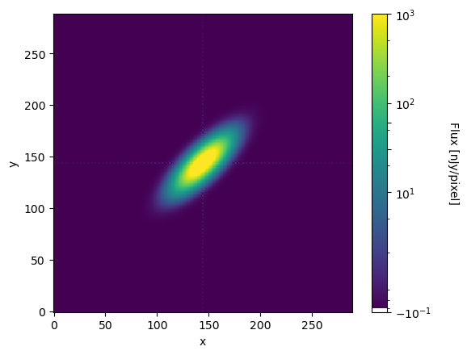

```python
ba = tab['exponential_reff_minor'][0]/tab['exponential_reff_major'][0]
use_beta = (tab['exponential_theta'][0] + 90) * gs.degrees
sm = gs.Sersic(n=1, half_light_radius=tab['exponential_reff_major'][0] * np.sqrt(ba),
               flux=tab['i_exponentialFlux'][0]).shear(q=ba, beta=use_beta)

exp_model = sm.drawImage(nx=img_w, ny=img_h, scale=arcsec_per_pix).array

print('Total flux of model = ', np.sum(exp_model), 'nJy, very close to flux from Object table = ',
      tab['i_exponentialFlux'][0], ' nJy')

fig, ax = plt.subplots()
im = ax.imshow(exp_model, origin='lower', interpolation='nearest', vmin=0, vmax=1000, norm='asinh')
cbar = fig.colorbar(im, ax=ax)
cbar.set_label('Flux [nJy/pixel]', rotation=270, labelpad=25)
cbar.set_ticks([-0.1, 10, 30, 60, 100, 1000])
plt.xlabel('x')
plt.ylabel('y')
plt.show()
```

> **Figure 3:** The best fit exponential Sersic model of the galaxy (i.e. Sersic index n is fixed to one) for the galaxy in Figure 1. This model was used to measure `exponentialFlux` of the galaxy.

### 5.2. cModel Reconstruction

The `cModel` fluxes are measured using the `meas_modelfit` algorithm. It does an initial guess to identify the centroid and preliminary shape moments, and then models the galaxy as an exponential disk with `n=1` (to generate `exp_reff` and `expFlux`), then models the galaxy as a bulge with a deVaucouleurs profile using `n=4` (to generate `dev_r`, `devFlux`, then fits a model as a linear combination of those, where the amplitudes (or fraction of flux, `fracDev`) are left free, with the resulting output stored as `cModel` fluxes.

First, store the parameters of the two Sersic components for cModel.

```python
frac_dev = tab['i_cModel_fracDev'][0]
total_flux = tab['i_cModelFlux'][0]

bulge_flux = total_flux * frac_dev
bulge_ba = tab['i_cModel_dev_reff_minor']/tab['i_cModel_dev_reff_major']
bulge_reff = tab['i_cModel_dev_reff_major'][0] * np.sqrt(bulge_ba)
bulge_pa = tab['i_cModel_dev_theta'][0] + 90

disk_flux = total_flux * (1.0 - frac_dev)
disk_ba = tab['i_cModel_exp_reff_minor']/tab['i_cModel_exp_reff_major']
disk_reff = tab['i_cModel_exp_reff_major'][0] * np.sqrt(disk_ba)
disk_pa = tab['i_cModel_exp_theta'][0] + 90
```

The cell below demonstrates how to reconstruct the intrinsic `cModel` light profile of the galaxy using these parameters.

```python
disk = gs.Exponential(flux=disk_flux, half_light_radius=disk_reff)
disk = disk.shear(q=disk_ba, beta=disk_pa * gs.degrees)

bulge = gs.DeVaucouleurs(flux=bulge_flux, half_light_radius=bulge_reff)
bulge = bulge.shear(q=bulge_ba, beta=bulge_pa * gs.degrees)

cmodel_galaxy = disk + bulge
```

Next, have `galsim` generate an image of the best `cModel` shape.

> **Warning**: The following cell produces a pink warning message that is safe to ignore. It appears because the de Vaucouleurs profiles have sharp central cusps and also large wings which ideally requires a large grid of frequencies for the Fast Fourier Transform (FFT). Because this demonstration is only visualizing the light profile, and is not concerned with re-calculating photometry with high accuracy, this warning can be safely ignored.

```python
cmodel = cmodel_galaxy.drawImage(nx=img_w, ny=img_h, scale=arcsec_per_pix).array
```

```
/opt/lsst/software/stack/conda/envs/lsst-scipipe-12.3.0-exact/lib/python3.13/site-packages/galsim/errors.py:441: GalSimFFTSizeWarning: drawFFT requires a very large FFT.
The required FFT size would be 11390 x 11390, which requires 2.90 GB of memory.
If you can handle the large FFT and want to suppress this warning,
you may update gsparams.maximum_fft_size.
  warnings.warn(GalSimFFTSizeWarning(message, size))
```

Finally, visualize the model of the observations.

```
Total flux of model =  2.1509728e+06 nJy, very close to flux from Object table =  2.29825e+06  nJy
```

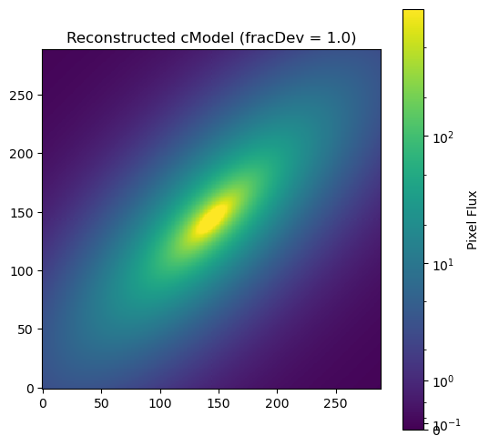

```python
plt.figure(figsize=(6, 6))
plt.imshow(cmodel, origin='lower', interpolation='nearest', vmin=0,
           vmax=1000, norm='asinh')

print('Total flux of model = ', np.sum(cmodel),
      'nJy, very close to flux from Object table = ',
      tab['i_cModelFlux'][0], ' nJy')

plt.title(f"Reconstructed cModel (fracDev = {frac_dev})")
plt.colorbar(label='Pixel Flux')
plt.show()
```

> **Figure 4:** Reconstructed light profile using the cModel bulge plus disk 2 component model.

## 6. Apply PSF convolution

Sections 4-5 visualized the intrinsic light profile (without the instrumental effect due to the PSF). Below, reconstruct the PSF at the location of the galaxy using the metadata stored in the `deep_coadd` image cutout, and convolve the intrinsic light profile with the PSF.

```python
target_x = cutout.bbox.x.min + (cutout.bbox.x.max - cutout.bbox.x.min) / 2
target_y = cutout.bbox.y.min + (cutout.bbox.y.max - cutout.bbox.y.min) / 2

target_point = (target_x, target_y)

local_psf_image = cutout.psf.compute_kernel_image(x=target_x, y=target_y)
psf_array = local_psf_image.array

galsim_psf = gs.InterpolatedImage(gs.Image(psf_array), scale=arcsec_per_pix)

final_profile = gs.Convolve([cmodel_galaxy, galsim_psf])
```

```
Total flux of model =  2.150725e+06 nJy, very close to flux from Object table =  2.29825e+06  nJy
```

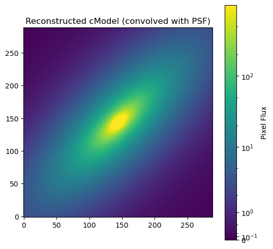

```python
img_w_psf = final_profile.drawImage(nx=img_w, ny=img_h, scale=arcsec_per_pix).array

plt.figure(figsize=(6, 6))
plt.imshow(img_w_psf, origin='lower', interpolation='nearest', vmin=0, vmax=1000, norm='asinh')

print('Total flux of model = ', np.sum(img_w_psf), 'nJy, very close to flux from Object table = ',
      tab['i_cModelFlux'][0], ' nJy')

plt.title("Reconstructed cModel (convolved with PSF)")
plt.colorbar(label='Pixel Flux')
plt.show()
```

> **Figure 5:** cModel light profile convolved with the PSF evaluated at the location of galaxy in the `deep_coadd`.